# Venture Tutorial Part 2

```python
from venture.venturemagics.ip_parallel import MRipl,display_directives,mk_p_ripl
make_ripl = mk_p_ripl
```

## Inferring the Mean and Variance of a Gaussian Distribution

### 1. Specifying and plotting the prior

These are the heights of a group of a 18-year-old men. We'd like to make an inference about the population based on this data.

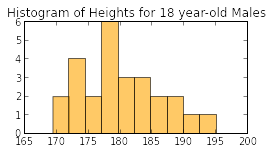

```python
male18=[179,195.1,183.7,178.7,171.5,181.8,172.5,
        174.6,190.4,173.8,172.6,185.2,178.4,
        177.6,183.5,178.1,177,172.9,188.4,169.4,
        180.2,189,182.4,185.8,180.7,178.7]
data=male18
fig,ax=plt.subplots(figsize=(4,2))
ax.hist(data, alpha=.6, color='orange')
ax.set_title('Histogram of Heights for 18 year-old Males');
```

We model the population distribution as a Gaussian with unknown mean `mu` and standard deviation `sigma`. We place broad priors on each of the variables. We then define `x` as a stochastic procedure that samples a height i.i.d. given `mu` and `sigma`.

```python
v=MRipl(80)
```

```
Failed to create IPython Parallel Client object.
MRipl is running in local (serial) model.
```

```python
%%venture v
[assume mu (normal 0 60) ]
[assume sigma (gamma 2 .2) ]
[assume x (lambda () (normal mu sigma) ) ]
```

```
Ripl 0 of 80:  [8.035116487120552, 11.607440026103758, 'unknown']
Ripl 1 of 80:  [18.383970739828563, 8.336089577294677, 'unknown']
Ripl 2 of 80:  [-78.18634280929683, 8.730709432215562, 'unknown']
Ripl 3 of 80:  [-45.46512864514391, 29.04919461163236, 'unknown']
Ripl 4 of 80:  [-76.36545111627048, 2.3106878954474257, 'unknown']
...
```

We can visualize our prior on `mu` and `sigma`, as well as their covariance, via the 'scatter' option for `snapshot`.

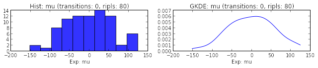

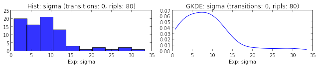

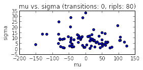

```python
v.snapshot(('mu','sigma'), plot=True, scatter=True);
```

Each pair (`mu`, `sigma`) produces a distinct Gaussian population distribution generated from sampling `x`. Using the MRipl method `sample_populations`, we can plot some of these populations (sampled from the model prior).

The form is: `python <mripl>.sample_populations(<stochastic_expression>, <number_populations>, <population_size>)`

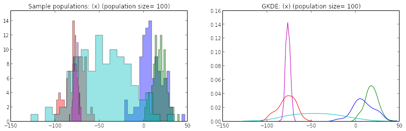

```python
out=v.sample_populations('(x)', 5, 100)
```

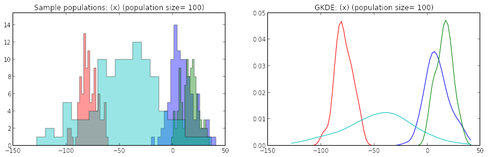

```python
out=v.sample_populations('(x)', 4, 100)
```

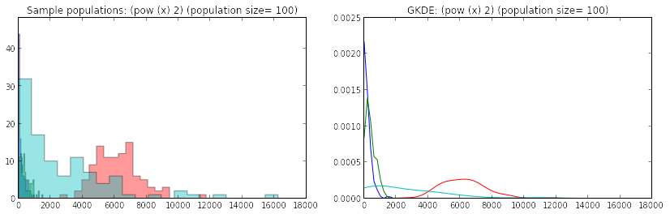

```python
squared_x = v.sample_populations('(pow (x) 2)', 4, 100)
```

If we sample a population from each RIPL in the MRipl and collapse all individuals into one big population, we get an approximation of the marginal prior on heights.

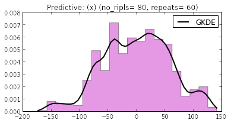

```python
outs=v.snapshot('(x)', plot=True, repeat=60)
```

### 2. Conditioning the model on data

We condition the model using the `observe` directive. As with the 'Tricky Coin' example, we can either condition *incrementally*, interleaving `observe` and `infer` directives, or we can condition on all the data at once. Here we exhibit incremental conditioning.

```
Observed data:  [179]
```

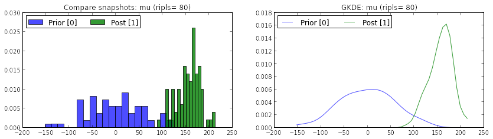

```python
prior_mu = v.snapshot('mu')

v.observe('(x)', data[0] )
print 'Observed data: ', data[:1]

v.infer(500)
posterior1_mu=v.snapshot('mu')
fig = v.compare_snapshots( (prior_mu,posterior1_mu) )
```

```
Observed data:  [179, 195.1]
```

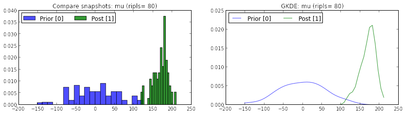

```python
v.observe('(x)',data[1] )
print 'Observed data: ', data[:2]

v.infer(500)
posterior2_mu=v.snapshot('mu')

# NOTE: we are comparing the posterior given two data-points to the original prior:
# i.e. the prior before conditioning on any data
fig = v.compare_snapshots( (prior_mu,posterior2_mu) )
```

```
Observed data:  [179, 195.1, 183.7, 178.7]
```

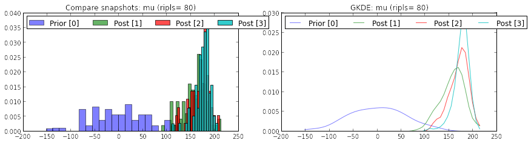

```python
v.observe('(x)', data[2] )
v.observe('(x)', data[3] )
print 'Observed data: ', data[:4]

v.infer(500)
posterior3_mu=v.snapshot('mu')
fig = v.compare_snapshots( (prior_mu, posterior1_mu, posterior2_mu, posterior3_mu) )
```

[figure not shown]

```python
populations=v.sample_populations('(x)', 3, 90);
```

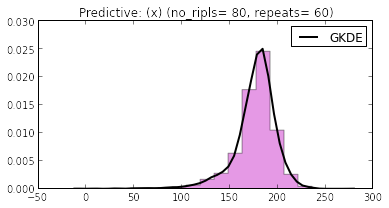

```python
posterior_marginal_x = v.snapshot('(x)', plot=True, repeat=60)
```

## Making inference robust to outliers

```python
from venture.venturemagics.ip_parallel import MRipl
male18=[179,195.1,183.7,178.7,171.5,181.8,172.5,
        174.6,190.4,173.8,172.6,185.2,178.4,
        177.6,183.5,178.1,177,172.9,188.4,169.4,
        180.2,189,182.4,185.8,180.7,178.7]
data=male18
v=MRipl(20,local_mode=True)
```

```python
%%venture v
[assume mu (normal 0 60) ]
[assume sigma (gamma 2 .2) ]
[assume x (lambda () (normal mu sigma))]
```

```
Ripl 0 of 20:  [8.035116487120552, 11.607440026103758, 'unknown']
Ripl 1 of 20:  [18.383970739828563, 8.336089577294677, 'unknown']
Ripl 2 of 20:  [-78.18634280929683, 8.730709432215562, 'unknown']
Ripl 3 of 20:  [-45.46512864514391, 29.04919461163236, 'unknown']
Ripl 4 of 20:  [-76.36545111627048, 2.3106878954474257, 'unknown']
...
```

```python
[v.observe('(x)',datum) for datum in data[:20]]
print 'Observed data:', data[:20]
v.infer(600)
posterior_before_outlier=v.snapshot('mu',plot=True);
```

[output not shown]

```python
v.observe('(x)',500)
v.infer(600)
posterior_after_outlier=v.snapshot('mu')
shift_due_outlier = v.compare_snapshots( (posterior_before_outlier, posterior_after_outlier) );
```

[output not shown]

[output cut: 31 more lines]

[output not shown]

```python
v_robust = MRipl(20)
```

```python
%%venture v_robust
[assume mu (normal 0 60) ]
[assume sigma (gamma 2 .2) ]
[assume x (lambda () (if (flip .99) (normal mu sigma) (normal mu (* (gamma 5 1) sigma) ) ) ) ]
```

```python
[v_robust.observe('(x)',datum) for datum in data[:20]]
v_robust.infer(600)
posterior_before_outlier = v_robust.snapshot('mu')

v_robust.observe('(x)',500)

v_robust.infer(600)
posterior_after_outlier = v_robust.snapshot('mu')

print 'Observed data:', data[:20]+[400]
out = v_robust.compare_snapshots( (posterior_before_outlier, posterior_after_outlier) )
```

[output not shown]

```python
print 'basic model mean logscore: ', np.mean(v.get_global_logscore())
print 'robust model mean logscore: ', np.mean(v_robust.get_global_logscore())
```

[output not shown]